# Estimating the FoI from the PR

Including: `pr2foi`, `foi2pr`, `pr2ar`, `ar2pr`, `pr2ar`, `ar2pr`

David Smith

2/21/2022

For a more general guide to the estimation utilities of RAMP, see Estimation.html

## .

The `pr2foi` or `pr2ar` algorithms translate data about the PR into an estimate of exposure using a mechanistic model defined over a state space, $\cal X$, and a dynamical cohort model:
$$\frac{d{\cal X}}{da}.$$
Here, we are assuming that $h$ is constant over time, so we are evaluating the static patterns.

Here, we present a prototype based on an old published paper. In `Variants`, we present a list of other functions.

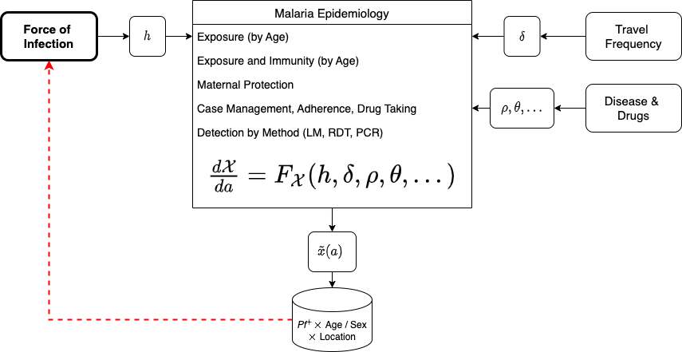

## FoI and AR

```r
foi2ar= function(h,D=1){
  1-exp(-h/D)
}
```

```r
ar2foi = function(ar,D=1){
  -log(1-ar)*D
}
```

This code demonstrates the two functions are each others inverses.

```r
ar2foi(foi2ar(.1, 10), 10)
foi2ar(ar2foi(.1, 10), 10)
```

[output not shown]

## Pseudocode

- Pass a set of triplets $(a,X,N)$ to a function where
  - $a$ is the age
  - $X(a)$ is the number *P. falciparum* positive by LM or RDT
  - $N(a)$ is the number sampled.
- Using a model that predicts the proportion positive by LM or RDT by age, $x\left(a|h\right)$, computes the log-likelihood of the FoI $h$ given $a$, $x$, and $N$,
  $${\cal L}(h) = X \log x(a|h) + (N-X) \log (1-x(a|h))$$
- Maximize the likelihood of $h$.

## Generic

```r
foi2pr = function(h,a,Par){
  UseMethod("foi2pr", Par)
}
```

```r
pr2foi_optimize = function(X,a,N,Par){
  lik_h = function(h, a, X, N, Par) {
    ppr = foi2pr(h,a,Par)
    -sum(X*log(ppr) + (N-X)*log(1-ppr))
  }
  optimize(lik_h, c(0,80/365), a=a, X=X, N=N, Par=Par)$minimum
}
```

## Pull & Grab

### .

This function is from an analysis done in the 1970s:

- Pull, J.H., and Grab, B. (1974). A simple epidemiological model for evaluating the malaria inoculation rate and the risk of infection in infants. Bull. World Health Organ. 51, 507–516.

The equation predicting *Pf*PR by age is a slightly modified version of the Ross-Macdonald model:
$$\frac{dx}{da} = h(k-x) -rx.$$
The paramter $k$ is an artificial ceiling on the $x$.

```r
foi2pr.pg= function(h,a,Par){with(Par,{
  h*k/(h+r)*(1-exp(-(h+r)*a))
})}
```

```r
makePar_pg = function(r=1/200, k=1){
  Par.pg= list()
  Par.pg$r = r
  Par.pg$k = k
  class(Par.pg) <- "pg"
  return(Par.pg)
}
```

```r
Par.pg = makePar_pg()
```

### test

This is some code to test that it works.

### Data

These are the data in Table 1.

```r
# Table 1
a_pg = (c(0:11)*30 +15)
N1=c(39,38,59,69,55,55,48,48,63,48,55,50)
X1=c(0,3,16,26,26,32,29,29,34,31,31,34)
N2=c(50,52,63,42,46,67,68,71,54,48,50,55)
X2=c(1,4,23,23,21,41,37,48,30,31,34,32)
N3=c(45,57,59,59,52,65,46,50,65,63,55,46)
X3=c(1,7,17,25,17,27,18,25,30,34,29,27)
N4=c(52,55,54,40,57,56,57,50,59,40,44,54)
X4=c(0,12,20,17,29,40,37,26,41,25,24,39)
N_pg = N1+N2+N3+N4
X_pg = X1+X2+X3+X4
```

```r
# Table 2
cohort =c(507,443,320,222,131,79,39,21,16,6,4,1)
h1=c(12,82,73,64,33,26,11,5,3,1,2,0)
```

### Fit, Plot

```r
Par.pg$k = .63
pr_pg = X_pg/N_pg
Par.pg$r = 1/120
Par.pg$k = 1
pr2foi_optimize(X_pg, a_pg, N_pg, Par.pg) -> v1
```

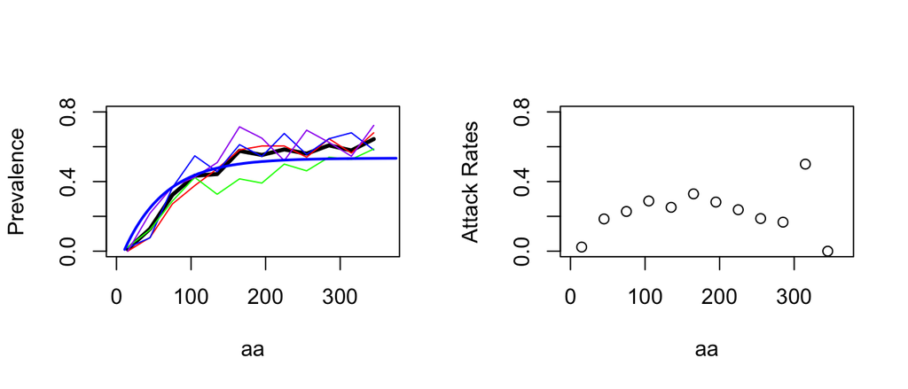

```r
par(mfrow = c(1,2))
aa = 1:365
plot(aa, 0*aa, ylim = c(0,.8), type = "n", ylab = "Prevalence")
lines(a_pg, X_pg/N_pg, lwd=3)
lines(a_pg, X1/N1, col = "red")
lines(a_pg, X2/N2, col = "blue")
lines(a_pg, X3/N3, col = "green")
lines(a_pg, X4/N4, col = "purple")
lines(aa+10, foi2pr(v1, aa, Par.pg), lwd=2, col ="blue")
plot(aa, 0*aa, ylim = c(0,0.8), type = "n", ylab = "Attack Rates")
points(a_pg, h1/cohort)
```

```r
mis15 = read.csv("../BiokoIsland/data/mismap2015.csv", header=TRUE)
ix = which(mis15$age>0 & mis15$age<8)
#par1=makePar_PUXx()
par1=makePar_pg()
pf=mis15$pf[ix]
a=mis15$age[ix]*365
N=0*mis15$age[ix]+1
unique(a)
```

```
##  [1]  365.00 1460.00  302.95 2555.00 1825.00 1095.00 2190.00   29.20  730.00
## [10]  182.50  335.80   91.25   62.05  244.55  153.30  211.70  273.75  120.45
## [19]   14.60  149.65  240.90    7.30  332.15   18.25
```

```r
pr2foi_optimize(pf, a, N, par1)*365
```

```
## [1] 0.2484496
```

## Variants

- pr2foi - xDE prototype

```r
source("../Estimation/pr2foi.PUXx.R")
```

```r
modPar.PUXx = makePar_PUXx()
modPar.PUXx$k3=1/100
modPar.PUXx$deltaU=0
modPar.PUXx$deltaX=1/365
modPar.PUXx$rho=0
modPar.PUXx$s=1
modPar.PUXx$N=10
pr2foi_optimize(X_pg, a_pg, N_pg, modPar.PUXx) -> v2
```

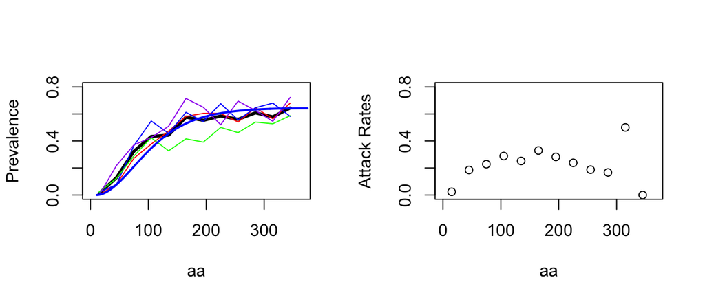

```r
par(mfrow = c(1,2))
aa = 1:365
plot(aa, 0*aa, ylim = c(0,.8), type = "n", ylab = "Prevalence")
lines(a_pg, X_pg/N_pg, lwd=3)
lines(a_pg, X1/N1, col = "red")
lines(a_pg, X2/N2, col = "blue")
lines(a_pg, X3/N3, col = "green")
lines(a_pg, X4/N4, col = "purple")
lines(aa+10, foi2pr(v2, aa, modPar.PUXx), lwd=2, col ="blue")
plot(aa, 0*aa, ylim = c(0,0.8), type = "n", ylab = "Attack Rates")
points(a_pg, h1/cohort)
```

```r
c(v1*365,v2*365)
```

```
## [1]  3.489821 27.184423
```